# YouTube Analysis

### Initial Setup

Read in the data from the file:

```r
dat <- read.csv('youtube_experiment.csv')
nrow(dat)
```

```
## [1] 1038
```

How many duplicate responses do we have?

```r
summary(duplicated(dat["workerId"]))
```

```
##    Mode   FALSE    NA's
## logical    1038       0
```

What are the column names?

```r
names(dat)
```

```
##  [1] "workerId"
##  [2] "Time_spent_page_1"
##  [3] "Time_spent_survey_1"
##  [4] "Condition"
##  [5] "Video"
##  [6] "Pinterest.Which.of.the.following.social.media.platforms.do.you.have.an.account.on."
##  [7] "Instagram.Which.of.the.following.social.media.platforms.do.you.have.an.account.on."
##  [8] "Facebook.Which.of.the.following.social.media.platforms.do.you.have.an.account.on."
##  [9] "Twitter.Which.of.the.following.social.media.platforms.do.you.have.an.account.on."
## [10] "YouTube.Which.of.the.following.social.media.platforms.do.you.have.an.account.on."
## [11] "Snapchat.Which.of.the.following.social.media.platforms.do.you.have.an.account.on."
## [12] "Facebook.How.often.do.you.visit.each.of.the.following.social.media.platforms."
## [13] "Instagram.How.often.do.you.visit.each.of.the.following.social.media.platforms."
## [14] "Twitter.How.often.do.you.visit.each.of.the.following.social.media.platforms."
## [15] "Pinterest.How.often.do.you.visit.each.of.the.following.social.media.platforms."
```

[output cut: 38 more lines]

### Data Wrangling

Rename the columns:

```r
dat <- dat %>% rename(video.impression = `What.is.your.overall.impression.of.the.video.`,
                      item.impression = `After.watching.the.video..what.is.your.overall.impression.of.the.item.shown.in.the.image.above.`,
                      creator.favors = `How.much.do.you.think.the.video.creator.favors.the.item.shown.in.the.image.above.`,
                      relationship = `How.likely.do.you.think.there.is.a.relationship.between.the.video.creator.and.the.organization.selling.the.item.`,
                      age = `In.which.year.were.you.born.`,
                      gender = `What.is.your.gender.`,
                      education = `What.is.the.highest.level.of.education.you.have.completed.`,
                      income = `What.is.your.annual.household.income.`,
                      account.youtube = `YouTube.Which.of.the.following.social.media.platforms.do.you.have.an.account.on.`,
                      visit.youtube = `YouTube.How.often.do.you.visit.each.of.the.following.social.media.platforms.`,
                      post.youtube = `YouTube.How.often.do.you.post.content.on.each.of.the.following.social.media.platforms.`)
```

Modify the demographics:

```r
dat <- dat %>% mutate(age = 2018 - age)
```

Change the relevant columns to factors:

```r
dat <- dat %>% mutate(Condition = factor(Condition),
                      Video = factor(Video),
                      VideoId = factor(VideoId))

levels(dat$Video) <- c("Cat", "Makeup", "Hotel", "Drone", "RecordPlayer")
levels(dat$Condition) <- c("Control", "AffTop", "AffBottom", "ExplTop", "ExplBottom", "SupportTop", "SupportBottom")
```

Create a new column indicating the disclosure type:

```r
dat <- dat %>% mutate(Disclosure = ifelse(Condition == "ExplTop" | Condition == "ExplBottom", "Expl", ifelse(Condition == "AffTop" | Condition == "AffBottom", "Aff", ifelse(Condition == "SupportTop" | Condition == "SupportBottom", "Support", "Control"))))
```

Change the relevant columns to numeric:

```r
summary(dat$video.impression)
```

```
## Extremely Negative Extremely Positive            Neutral
##                 37                286                182
##  Somewhat Negative  Somewhat Positive
##                120                413
```

```r
dat <- dat %>% mutate(video.impression = (factor(video.impression, levels=c("Extremely Negative", "Somewhat Negative", "Neutral", "Somewhat Positive", "Extremely Positive"))))
summary(dat$video.impression)
```

```
## Extremely Negative  Somewhat Negative            Neutral
##                 37                120                182
##  Somewhat Positive Extremely Positive
##                413                286
```

```r
dat <- dat %>% mutate(video.impression_numeric = as.numeric(video.impression))
summary(dat$video.impression_numeric)
```

```
##    Min. 1st Qu.  Median    Mean 3rd Qu.    Max.
##   1.000   3.000   4.000   3.762   5.000   5.000
```

```r
summary(dat$item.impression)
```

```
## Extremely Negative Extremely Positive            Neutral
##                 22                209                299
##  Somewhat Negative  Somewhat Positive
##                 51                457
```

```r
dat <- dat %>% mutate(item.impression = (factor(item.impression, levels=c("Extremely Negative", "Somewhat Negative", "Neutral", "Somewhat Positive", "Extremely Positive"))))
summary(dat$item.impression)
```

```
## Extremely Negative  Somewhat Negative            Neutral
##                 22                 51                299
##  Somewhat Positive Extremely Positive
##                457                209
```

```r
dat <- dat %>% mutate(item.impression_numeric = as.numeric(item.impression))
summary(dat$item.impression)
```

```
## Extremely Negative  Somewhat Negative            Neutral
##                 22                 51                299
##  Somewhat Positive Extremely Positive
##                457                209
```

```r
summary(dat$creator.favors)
```

```
## Does Not Favor At All     Moderately Favors       Slightly Favors
##                    33                   342                    76
##       Somewhat Favors       Strongly Favors
##                   178                   409
```

```r
dat <- dat %>% mutate(creator.favors = (factor(creator.favors, levels=c("Does Not Favor At All", "Slightly Favors", "Somewhat Favors", "Moderately Favors", "Strongly Favors"))))
summary(dat$creator.favors)
```

```
## Does Not Favor At All       Slightly Favors       Somewhat Favors
##                    33                    76                   178
##     Moderately Favors       Strongly Favors
##                   342                   409
```

```r
dat <- dat %>% mutate(creator.favors_numeric = as.numeric(creator.favors))
summary(dat$creator.favors)
```

```
## Does Not Favor At All       Slightly Favors       Somewhat Favors
##                    33                    76                   178
##     Moderately Favors       Strongly Favors
##                   342                   409
```

```r
summary(dat$relationship)
```

```
##   Extremely Likely Extremely Unlikely            Neutral
##                251                 51                187
##    Somewhat Likely  Somewhat Unlikely
##                395                154
```

```r
dat <- dat %>% mutate(relationship = (factor(relationship, levels=c("Extremely Unlikely", "Somewhat Unlikely", "Neutral", "Somewhat Likely", "Extremely Likely"))))
summary(dat$relationship)
```

```
## Extremely Unlikely  Somewhat Unlikely            Neutral
##                 51                154                187
##    Somewhat Likely   Extremely Likely
##                395                251
```

```r
dat <- dat %>% mutate(relationship_numeric = as.numeric(relationship))
summary(dat$relationship)
```

```
## Extremely Unlikely  Somewhat Unlikely            Neutral
##                 51                154                187
##    Somewhat Likely   Extremely Likely
##                395                251
```

### User Demographics

How old were the users?

```r
summary(dat$age)
```

```
##    Min. 1st Qu.  Median    Mean 3rd Qu.    Max.
##   19.00   29.00   35.00   37.78   44.00  118.00
```

```r
sd(dat$age)
```

```
## [1] 12.1061
```

How were they distributed by gender?

```r
rowPerc(xtabs(~gender, data=dat))
```

```
##
## gender Female Male Other Prefer not to answer Total
##         46.72 52.6  0.48                 0.19   100
```

How were they distributed by education?

```r
rowPerc(xtabs(~education, data=dat))
```

```
##
## education Associate's Degree Bachelor's Degree Doctoral Degree
##                        13.01             37.19            1.06
##
## education High School Graduate Master's Degree No High School
##                          11.27            7.61            0.1
##
## education Prefer not to answer Professional Degree (e.g., MBA, J.D.)
##                           0.67                                  2.22
##
## education Some College Total
##                  26.88   100
```

How many users do we have in each condition across the survey?

```r
xtabs(~Condition + Video, data=dat)
```

```
##                Video
## Condition       Cat Makeup Hotel Drone RecordPlayer
##   Control        28     30    28    35           24
##   AffTop         34     38    30    37           43
##   AffBottom      29     34    21    31           35
##   ExplTop        29     25    31    27           29
##   ExplBottom     30     33    22    41           17
##   SupportTop     28     27    24    24           21
##   SupportBottom  37     27    34    27           28
```

How many users do we have in each disclosure across the suvrey?

```r
xtabs(~Disclosure + Video, data=dat)
```

```
##           Video
## Disclosure Cat Makeup Hotel Drone RecordPlayer
##    Aff      63     72    51    68           78
##    Control  28     30    28    35           24
##    Expl     59     58    53    68           46
##    Support  65     54    58    51           49
```

How many users vs non-users do we have?

```r
rowPerc(xtabs(~account.youtube, data=dat))
```

```
##
## account.youtube   No Not Sure   Yes Total
##                 6.55     1.83 91.62   100
```

How often do users visit youtube?

```r
rowPerc(xtabs(~visit.youtube, data=dat))
```

```
##
## visit.youtube A Few Times A Week About Once A Day Every Few Weeks
##                            17.05            21.48            3.37
##
## visit.youtube Less Often Never Not Sure Several Times A Day Total
##                     1.25  1.45      0.1                55.3   100
```

How often do users post on youtube?

```r
rowPerc(xtabs(~post.youtube, data=dat))
```

```
##
## post.youtube A Few Times A Week About Once A Day Every Few Weeks
##                            5.49             4.14            9.63
##
## post.youtube Less Often Never Not Sure Several Times A Day Total
##                   27.84 46.53     0.48                5.88   100
```

Let’s write a simple graphing utility.

```r
likert_plot <- function(data, video_factor, col) {
  filt_data <- data %>% filter(Video == video_factor)
  cols <- c(col)
  cols <- setNames(cols, c(video_factor))
  likert_data <- likert(filt_data %>% select(col) %>% rename_(.dots=cols), grouping=filt_data$Condition)
  return(plot(likert_data, centered=FALSE, legend.position="none"))
}

grid_likert_plot <- function(data, col) {
  p1 <- likert_plot(data, "Cat", col)
  p2 <- likert_plot(data, "Makeup", col)
  p3 <- likert_plot(data, "Hotel", col)
  p4 <- likert_plot(data, "Drone", col)
  p5 <- likert_plot(data, "RecordPlayer", col)

  return(grid.arrange(p1, p2, p3, p4, p5))
}
```

Let’s also write a utility that will generate the logit plot.

```r
po_plot_helper <- function(data, video_factor, col) {
  filt_data <- data %>% filter(Video == video_factor)
  mat <- as.data.frame.matrix(xtabs(formula(paste0("~Condition + ", col)), filt_data))

  new_mat <- matrix(nrow=7, ncol=4)

  for(i in 1:4) {
     first_set <- mat[, c(1:i)]
     second_set <- mat[, c((i+1):5)]

     if(!is.null(dim(first_set))) {
        first_set <- as.integer(rowSums(first_set))
     }

      if(!is.null(dim(second_set))) {
        second_set <- as.integer(rowSums(second_set))
     }

     result = log(first_set/second_set)

     new_mat[, i] <- result
  }

  rownames(new_mat) <- rownames(mat)
  return(ggplot(melt(new_mat), aes(x=Var1, y=value, col=factor(Var2), group=factor(Var2))) + geom_line() + xlab("Condition") + ylab("Logits") + theme(axis.text.x = element_text(angle = 45, hjust = 1), legend.position="none") + ggtitle(video_factor))
}

po_plot <- function(data, col) {
  p1 <- po_plot_helper(data, "Cat", col)
  p2 <- po_plot_helper(data, "Makeup", col)
  p3 <- po_plot_helper(data, "Hotel", col)
  p4 <- po_plot_helper(data, "Drone", col)
  p5 <- po_plot_helper(data, "RecordPlayer", col)

  return(grid.arrange(p1, p2, p3, p4, p5))
}
```

### What is your overall impression of the video?

Let’s first examine the distribution of this question across the different videos.

```r
xtabs(~Condition + video.impression, data=dat)
```

```
##                video.impression
## Condition       Extremely Negative Somewhat Negative Neutral
##   Control                        3                23      18
##   AffTop                         6                23      26
##   AffBottom                      7                15      27
##   ExplTop                        5                17      33
##   ExplBottom                     6                12      24
##   SupportTop                     4                14      25
##   SupportBottom                  6                16      29
##                video.impression
## Condition       Somewhat Positive Extremely Positive
##   Control                      53                 48
##   AffTop                       73                 54
##   AffBottom                    61                 40
##   ExplTop                      52                 34
##   ExplBottom                   64                 37
##   SupportTop                   48                 33
##   SupportBottom                62                 40
```

Let’s visualize the data.

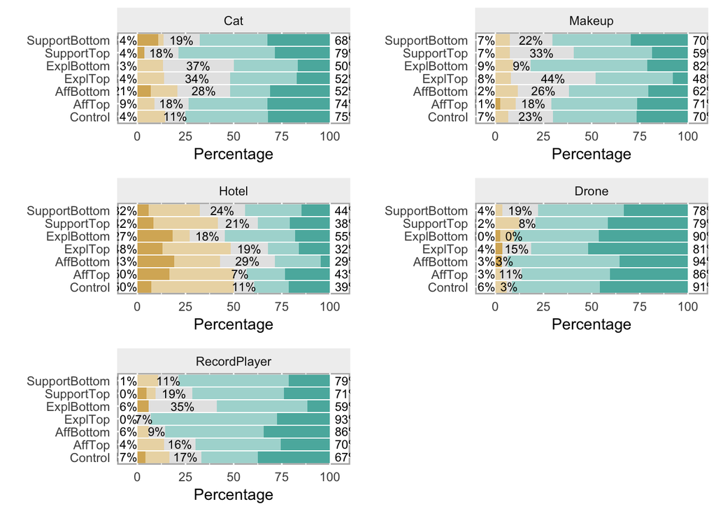

```r
grid_likert_plot(dat, "video.impression")
```

Let’s visualize the logits.

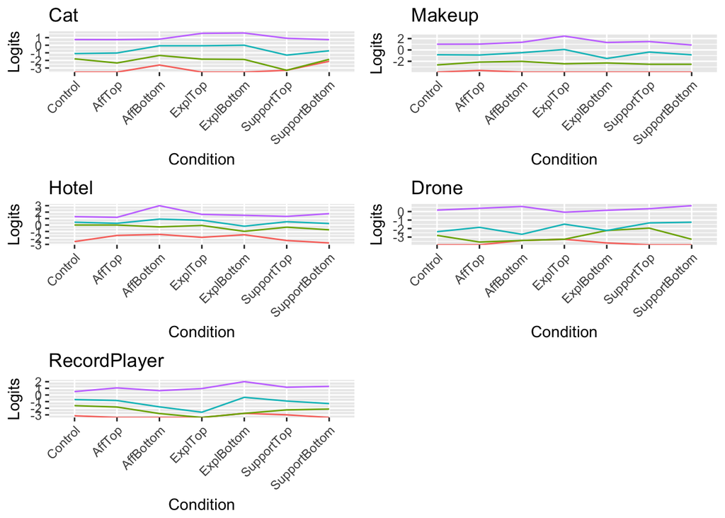

```r
po_plot(dat, "video.impression")
```

Next, let’s build a ordinal regression model.

```r
model <- clmm2(video.impression ~ Condition, random=Video, data=dat, Hess = TRUE)
summary(model)
```

```
## Cumulative Link Mixed Model fitted with the Laplace approximation
##
## Call:
## clmm2(location = video.impression ~ Condition, random = Video,
##     data = dat, Hess = TRUE)
##
## Random effects:
##             Var   Std.Dev
## Video 0.4485745 0.6697571
##
## Location coefficients:
##                        Estimate Std. Error z value Pr(>|z|)
## ConditionAffTop        -0.1035   0.2083    -0.4971 0.6191156
## ConditionAffBottom     -0.2160   0.2153    -1.0032 0.3157789
## ConditionExplTop       -0.2998   0.2174    -1.3794 0.1677647
## ConditionExplBottom    -0.1512   0.2177    -0.6944 0.4874312
## ConditionSupportTop    -0.1558   0.2260    -0.6892 0.4906765
## ConditionSupportBottom -0.0893   0.2153    -0.4147 0.6783600
##
## No scale coefficients
##
## Threshold coefficients:
##                                      Estimate Std. Error z value
## Extremely Negative|Somewhat Negative -3.6259   0.3745    -9.6828
## Somewhat Negative|Neutral            -1.9562   0.3451    -5.6678
## Neutral|Somewhat Positive            -0.8512   0.3403    -2.5018
## Somewhat Positive|Extremely Positive  0.9749   0.3402     2.8656
##
## log-likelihood: -1396.446
## AIC: 2814.891
## Condition number of Hessian: 231.0572
```

```r
exp(coef(model))
```

```
## Extremely Negative|Somewhat Negative            Somewhat Negative|Neutral
##                           0.02662637                           0.14139273
##            Neutral|Somewhat Positive Somewhat Positive|Extremely Positive
##                           0.42688134                           2.65077663
##                      ConditionAffTop                   ConditionAffBottom
##                           0.90165396                           0.80574705
##                     ConditionExplTop                  ConditionExplBottom
##                           0.74094296                           0.85971257
##                  ConditionSupportTop               ConditionSupportBottom
##                           0.85574541                           0.91458856
##
##                           1.95376260
```

```r
exp(confint.default(model))
```

```
##                                           2.5 %     97.5 %
## Extremely Negative|Somewhat Negative 0.01278113 0.05546955
## Somewhat Negative|Neutral            0.07188502 0.27810945
## Neutral|Somewhat Positive            0.21911745 0.83164384
## Somewhat Positive|Extremely Positive 1.36082653 5.16349187
## ConditionAffTop                      0.59947742 1.35614759
## ConditionAffBottom                   0.52836316 1.22875394
## ConditionExplTop                     0.48391301 1.13449415
## ConditionExplBottom                  0.56113015 1.31717341
## ConditionSupportTop                  0.54948228 1.33270942
## ConditionSupportBottom               0.59975113 1.39469889
##                                              NA         NA
```

### What is your overall impression of the item?

Let’s first examine the distribution of this question across the different videos.

```r
xtabs(~Condition + item.impression, data=dat)
```

```
##                item.impression
## Condition       Extremely Negative Somewhat Negative Neutral
##   Control                        2                 9      42
##   AffTop                         4                 9      49
##   AffBottom                      3                 6      42
##   ExplTop                        3                 6      42
##   ExplBottom                     4                 9      38
##   SupportTop                     3                 4      44
##   SupportBottom                  3                 8      42
##                item.impression
## Condition       Somewhat Positive Extremely Positive
##   Control                      56                 36
##   AffTop                       85                 35
##   AffBottom                    69                 30
##   ExplTop                      62                 28
##   ExplBottom                   56                 36
##   SupportTop                   56                 17
##   SupportBottom                73                 27
```

Let’s visualize the data.

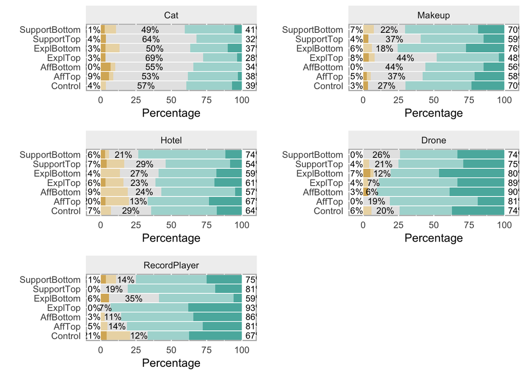

```r
grid_likert_plot(dat, "item.impression")
```

Let’s visualize the logits.

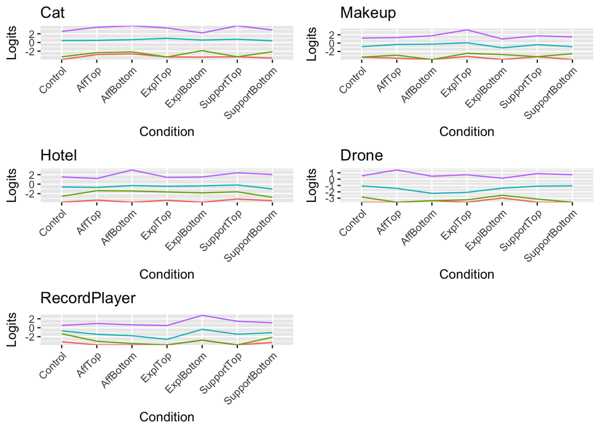

```r
po_plot(dat, "item.impression")
```

Next, let’s build a ordinal regression model.

```r
model <- clmm2(item.impression ~ Condition, random=Video, data=dat, Hess = TRUE)
summary(model)
```

```
## Cumulative Link Mixed Model fitted with the Laplace approximation
##
## Call:
## clmm2(location = item.impression ~ Condition, random = Video,
##     data = dat, Hess = TRUE)
##
## Random effects:
##             Var  Std.Dev
## Video 0.4350511 0.659584
##
## Location coefficients:
##                        Estimate Std. Error z value  Pr(>|z|)
## ConditionAffTop         -0.1569   0.2113    -0.7425 0.457755
## ConditionAffBottom      -0.0953   0.2189    -0.4353 0.663344
## ConditionExplTop        -0.1106   0.2220    -0.4982 0.618361
## ConditionExplBottom     -0.0240   0.2258    -0.1065 0.915222
## ConditionSupportTop     -0.3163   0.2284    -1.3844 0.166244
## ConditionSupportBottom  -0.0556   0.2187    -0.2541 0.799448
##
## No scale coefficients
##
## Threshold coefficients:
##                                      Estimate Std. Error z value
## Extremely Negative|Somewhat Negative  -4.1658   0.3965   -10.5062
## Somewhat Negative|Neutral             -2.9088   0.3541    -8.2154
## Neutral|Somewhat Positive             -0.7739   0.3374    -2.2940
## Somewhat Positive|Extremely Positive   1.3963   0.3393     4.1147
##
## log-likelihood: -1263.159
## AIC: 2548.318
## Condition number of Hessian: 146.9751
```

```r
exp(coef(model))
```

```
## Extremely Negative|Somewhat Negative            Somewhat Negative|Neutral
##                           0.01551800                           0.05454117
##            Neutral|Somewhat Positive Somewhat Positive|Extremely Positive
##                           0.46120512                           4.04017095
##                      ConditionAffTop                   ConditionAffBottom
##                           0.85480689                           0.90910066
##                     ConditionExplTop                  ConditionExplBottom
##                           0.89528722                           0.97624506
##                  ConditionSupportTop               ConditionSupportBottom
##                           0.72887218                           0.94595073
##
##                           1.93398772
```

```r
exp(confint.default(model))
```

```
##                                            2.5 %     97.5 %
## Extremely Negative|Somewhat Negative 0.007133981 0.03375512
## Somewhat Negative|Neutral            0.027248523 0.10917068
## Neutral|Somewhat Positive            0.238080624 0.89343753
## Somewhat Positive|Extremely Positive 2.077555075 7.85682241
## ConditionAffTop                      0.564979936 1.29331108
## ConditionAffBottom                   0.591916550 1.39625089
## ConditionExplTop                     0.579386636 1.38342717
## ConditionExplBottom                  0.627082059 1.51982407
## ConditionSupportTop                  0.465796778 1.14052884
## ConditionSupportBottom               0.616176833 1.45221750
##                                               NA         NA
```

### How much do you think the creator favors the item?

Let’s first examine the distribution of this question across the different videos.

```r
xtabs(~Condition + creator.favors, data=dat)
```

```
##                creator.favors
## Condition       Does Not Favor At All Slightly Favors Somewhat Favors
##   Control                           4               7              22
##   AffTop                            5              16              31
##   AffBottom                         6               8              21
##   ExplTop                           5              10              30
##   ExplBottom                        6              10              28
##   SupportTop                        1              16              16
##   SupportBottom                     6               9              30
##                creator.favors
## Condition       Moderately Favors Strongly Favors
##   Control                      54              58
##   AffTop                       61              69
##   AffBottom                    51              64
##   ExplTop                      44              52
##   ExplBottom                   40              59
##   SupportTop                   44              47
##   SupportBottom                48              60
```

Let’s visualize the data.

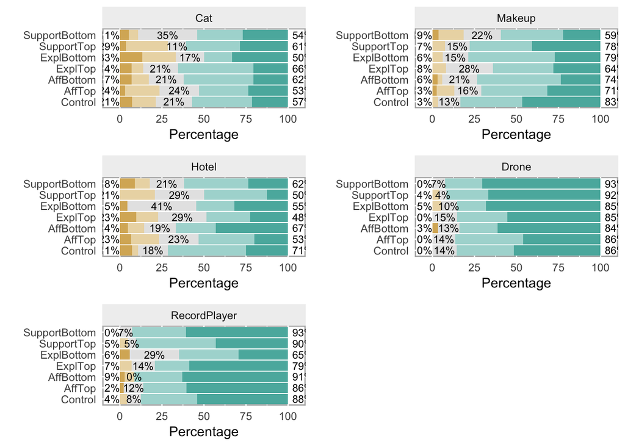

```r
grid_likert_plot(dat, "creator.favors")
```

Let’s visualize the logits.

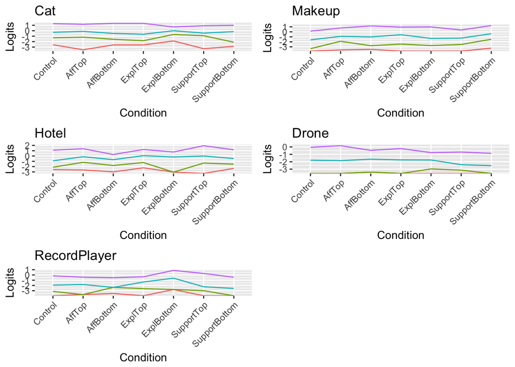

```r
po_plot(dat, "creator.favors")
```

Next, let’s build a ordinal regression model.

```r
model <- clmm2(creator.favors ~ Condition, random=Video, data=dat, Hess = TRUE)
summary(model)
```

```
## Cumulative Link Mixed Model fitted with the Laplace approximation
##
## Call:
## clmm2(location = creator.favors ~ Condition, random = Video,
##     data = dat, Hess = TRUE)
##
## Random effects:
##             Var   Std.Dev
## Video 0.4563455 0.6755335
##
## Location coefficients:
##                        Estimate Std. Error z value Pr(>|z|)
## ConditionAffTop        -0.2468   0.2070    -1.1920 0.23326249
## ConditionAffBottom      0.0083   0.2182     0.0379 0.96978893
## ConditionExplTop       -0.2268   0.2200    -1.0311 0.30250409
## ConditionExplBottom    -0.1737   0.2218    -0.7827 0.43377864
## ConditionSupportTop    -0.1155   0.2269    -0.5090 0.61075386
## ConditionSupportBottom -0.0693   0.2157    -0.3214 0.74789893
##
## No scale coefficients
##
## Threshold coefficients:
##                                       Estimate Std. Error z value
## Does Not Favor At All|Slightly Favors -3.7253   0.3805    -9.7910
## Slightly Favors|Somewhat Favors       -2.4169   0.3513    -6.8806
## Somewhat Favors|Moderately Favors     -1.1617   0.3424    -3.3927
## Moderately Favors|Strongly Favors      0.3733   0.3406     1.0961
##
## log-likelihood: -1329.347
## AIC: 2680.695
## Condition number of Hessian: 222.946
```

```r
exp(coef(model))
```

```
## Does Not Favor At All|Slightly Favors
##                            0.02410675
##       Slightly Favors|Somewhat Favors
##                            0.08919461
##     Somewhat Favors|Moderately Favors
##                            0.31295388
##     Moderately Favors|Strongly Favors
##                            1.45257383
##                       ConditionAffTop
##                            0.78132985
##                    ConditionAffBottom
##                            1.00829925
##                      ConditionExplTop
##                            0.79707256
##                   ConditionExplBottom
##                            0.84059029
##                   ConditionSupportTop
##                            0.89093495
##                ConditionSupportBottom
##                            0.93302043
##
##                            1.96508101
```

```r
exp(confint.default(model))
```

```
##                                            2.5 %     97.5 %
## Does Not Favor At All|Slightly Favors 0.01143598 0.05081638
## Slightly Favors|Somewhat Favors       0.04480632 0.17755707
## Somewhat Favors|Moderately Favors     0.15996263 0.61226882
## Moderately Favors|Strongly Favors     0.74508898 2.83183726
## ConditionAffTop                       0.52074526 1.17231281
## ConditionAffBottom                    0.65740409 1.54648775
## ConditionExplTop                      0.51791246 1.22670280
## ConditionExplBottom                   0.54418396 1.29844332
## ConditionSupportTop                   0.57111197 1.38985897
## ConditionSupportBottom                0.61134652 1.42395039
##                                               NA         NA
```

### How likely do you think there is a relationship between the content creator and the merchant?

Let’s first examine the distribution of this question across the different videos.

```r
xtabs(~Condition + relationship, data=dat)
```

```
##                relationship
## Condition       Extremely Unlikely Somewhat Unlikely Neutral
##   Control                        8                21      23
##   AffTop                        14                25      37
##   AffBottom                      8                21      28
##   ExplTop                        4                20      27
##   ExplBottom                     4                11      22
##   SupportTop                     7                23      23
##   SupportBottom                  6                33      27
##                relationship
## Condition       Somewhat Likely Extremely Likely
##   Control                    53               40
##   AffTop                     68               38
##   AffBottom                  56               37
##   ExplTop                    50               40
##   ExplBottom                 66               40
##   SupportTop                 50               21
##   SupportBottom              52               35
```

Let’s visualize the data.

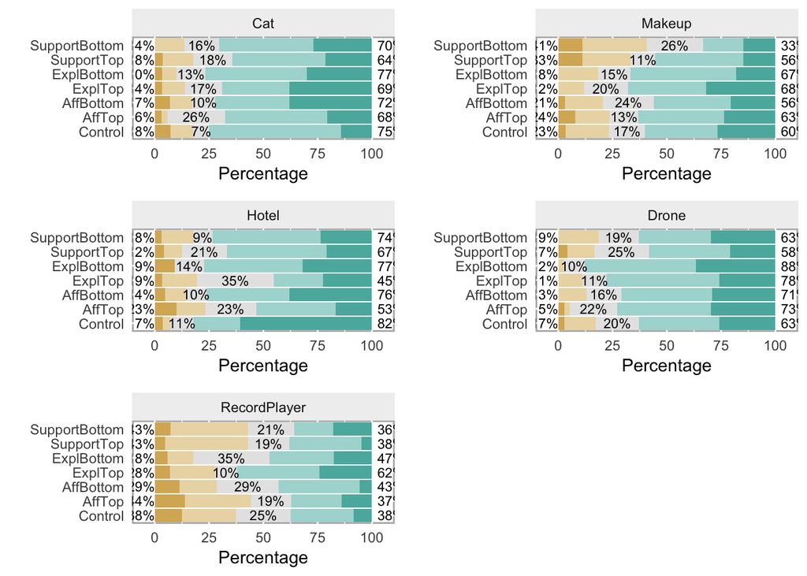

```r
grid_likert_plot(dat, "relationship")
```

Let’s visualize the logits.

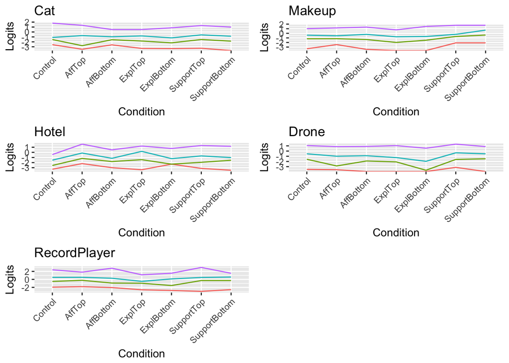

```r
po_plot(dat, "relationship")
```

Next, let’s build a ordinal regression model.

```r
model <- clmm2(relationship ~ Condition, random=Video, data=dat, Hess = TRUE)
summary(model)
```

```
## Cumulative Link Mixed Model fitted with the Laplace approximation
##
## Call:
## clmm2(location = relationship ~ Condition, random = Video, data = dat,
##     Hess = TRUE)
##
## Random effects:
##             Var   Std.Dev
## Video 0.1787674 0.4228089
##
## Location coefficients:
##                        Estimate Std. Error z value  Pr(>|z|)
## ConditionAffTop         -0.2378   0.2034    -1.1690 0.242423
## ConditionAffBottom      -0.0005   0.2131    -0.0023 0.998167
## ConditionExplTop         0.0796   0.2182     0.3646 0.715382
## ConditionExplBottom      0.2590   0.2133     1.2144 0.224600
## ConditionSupportTop     -0.3860   0.2218    -1.7404 0.081786
## ConditionSupportBottom  -0.3015   0.2125    -1.4191 0.155881
##
## No scale coefficients
##
## Threshold coefficients:
##                                      Estimate Std. Error z value
## Extremely Unlikely|Somewhat Unlikely  -3.1481   0.2783   -11.3108
## Somewhat Unlikely|Neutral             -1.5389   0.2502    -6.1510
## Neutral|Somewhat Likely               -0.5873   0.2457    -2.3901
## Somewhat Likely|Extremely Likely       1.1290   0.2474     4.5633
##
## log-likelihood: -1478.10
## AIC: 2978.20
## Condition number of Hessian: 187.7527
```

```r
exp(coef(model))
```

```
## Extremely Unlikely|Somewhat Unlikely            Somewhat Unlikely|Neutral
##                           0.04293482                           0.21462646
##              Neutral|Somewhat Likely     Somewhat Likely|Extremely Likely
##                           0.55581278                           3.09263690
##                      ConditionAffTop                   ConditionAffBottom
##                           0.78835694                           0.99951051
##                     ConditionExplTop                  ConditionExplBottom
##                           1.08281840                           1.29563574
##                  ConditionSupportTop               ConditionSupportBottom
##                           0.67978741                           0.73971826
##
##                           1.52624262
```

```r
exp(confint.default(model))
```

```
##                                           2.5 %     97.5 %
## Extremely Unlikely|Somewhat Unlikely 0.02488276 0.07408335
## Somewhat Unlikely|Neutral            0.13144068 0.35045862
## Neutral|Somewhat Likely              0.34337234 0.89968765
## Somewhat Likely|Extremely Likely     1.90427216 5.02260294
## ConditionAffTop                      0.52912667 1.17458955
## ConditionAffBottom                   0.65825177 1.51768868
## ConditionExplTop                     0.70601749 1.66071764
## ConditionExplBottom                  0.85298379 1.96799987
## ConditionSupportTop                  0.44014961 1.04989510
## ConditionSupportBottom               0.48778100 1.12178027
##                                              NA         NA
```